# 8: Cox Regression

Author

Thiago Cerqueira Silva

```r
# read "dta" files
library(haven)
# create table
library(gtsummary)
# data wrangling and other functions
library(tidyverse)
# if you want to have a output similar to stata
library(tidylog)
#cox
library(survival)
# plots survival
library(ggsurvfit)
# Limit significant digits to 2, remove scientific notation
options(digits = 2, scipen = 9)

# Import the dataset
trin <- read_dta("datasets/TRINMLSH.DTA")

#This contains data from a cohort study on cardiovascular risk factors and mortality among ~300 men from Trinidad.
# Some data wrangling

trin <- trin |>
  mutate(
    ethgp = factor(ethgp,
                      levels = c(1:5),
                      labels = c("African", "Indian", "European", "mixed", "Chin/Sem")),
    alc = factor(alc,
                      levels = c(0:3),
                      labels = c("none", "1-4/wk", "5-14/wk", ">=15/wk")),
    smoke3 = case_when(
      smokenum == 0 ~ "non-smok",
      smokenum == 1 ~ "ex-smok",
      !is.na(smokenum) ~ "smoker"
    ),
    smoke3 = fct_relevel(smoke3, "non-smok"),
    smokenum = factor(smokenum,
                      levels = c(0:5),
                      labels = c("non-smok", "ex-smok", "1-9/d", "10-19/d", "20-29/d", ">=30/d")),
    chdstart = factor(chdstart,
                      levels = c(0, 1),
                      labels = c("no", "yes")
    ))
```

# Q1

You don’t need to do any of this (stset) in R. Each regression can have its own time setting!

# Q2

Examine the effect of smoking on all-cause mortality using strate (or stptime if you prefer) and stcox. You may wish to recode smokenum into a smaller number of categories, say: 0=non-smoker, 1=ex-smoker, 2=current smoker.

We can now examine the smoking-specific mortality rates (per 1,000 person-years). Let’s first use the classical technique and then let’s use Cox regression.

```r
# Calculate rates
pyears(Surv(time = years, event=death) ~ smoke3, data = trin, scale = 1) %>%
  summary(n = F, rate = T, ci.r = T, scale = 1000)
```

Call: pyears(formula = Surv(time = years, event = death) ~ smoke3, data = trin, scale = 1)

number of observations = 317

| smoke3 | Events | Time | Event rate | CI (rate) |
| --- | --- | --- | --- | --- |
| non-smok | 30 | 984 | 30 | 21 - 44 |
| ex-smok | 18 | 462 | 39 | 23 - 62 |
| smoker | 40 | 749 | 53 | 38 - 73 |

```r
# Note that Surv() can take time data in two different formats: either a combination of data of entry and data of exit, or as a time # difference. In this case, `years` codes this time difference, so we'll use it.

# Create Cox model
cox_smok3 <- coxph(Surv(time = years, event=death) ~ smoke3, data = trin)

# Calculating 95% CIs for HRs
tbl_regression(cox_smok3, exponentiate = T) |>
  add_n(location="level") |>
  add_nevent(location="level")
```

| **Characteristic** | **N** | **Event N** | **HR** | **95% CI** | **p-value** |
| --- | --- | --- | --- | --- | --- |
| smoke3 |  |  |  |  |  |
| non-smok | 140 | 30 | — | — |  |
| ex-smok | 68 | 18 | 1.29 | 0.72, 2.32 | 0.4 |
| smoker | 109 | 40 | 1.75 | 1.09, 2.81 | 0.021 |

Abbreviations: CI = Confidence Interval, HR = Hazard Ratio

- N is the size of the group
- Event N is the number of events in that group

# Q3

Using the rates and rate ratios in part (2), can you see a trend in the relationship between smoking category and all-cause mortality? How would you assess this more formally? How would you present the results from your analyses in parts (2) and (3)?

```r
# Create Cox model
cox_smok3 <- coxph(Surv(time = years, event=death) ~ as.numeric(smoke3), data = trin)

# Calculating 95% CIs for HRs
tbl_regression(cox_smok3, exponentiate = T) |>
  add_n(location="level") |>
  add_nevent(location="level")
```

| **Characteristic** | **N** | **Event N** | **HR** | **95% CI** | **p-value** |
| --- | --- | --- | --- | --- | --- |
| as.numeric(smoke3) | 317 | 88 | 1.32 | 1.04, 1.68 | 0.020 |

Abbreviations: CI = Confidence Interval, HR = Hazard Ratio

**Answer**

You can assess the trend formally by treating the smoke variable as numeric (ordinal in this case), so the model will evaluate if the increase in each point is associated with increase in the hazard.

# Q4

Consider the possible confounding effect of current age on the relationship between smoking and mortality. By examining the data (but without performing any further modelling) would you expect a Cox model controlling for current age to give different results to one controlling for time in the study? Now perform a Cox model to investigate this.

**Answer**

Note that in question 2 the Cox model has adjusted for time in the study i.e. everyone is followed up from the time they enter the study and when an event occurs the comparison is with others who have the same amount of follow-up and not with others of the same age. If there are differences in age between the three groups then we would expect an analysis controlling for current age to show confounding (since mortality increases with age). One indicator of this would be the age at entry in the three groups.

```r
trin |>
  tbl_summary(include = ageent, by = smoke3) |>
  modify_caption("Age by smoke status")
```

Age by smoke status

| **Characteristic** | **non-smok** N = 140<sup>1</sup> | **ex-smok** N = 68<sup>1</sup> | **smoker** N = 109<sup>1</sup> |
| --- | --- | --- | --- |
| Age in years at first survey | 64.52 (62.32, 67.68) | 65.32 (62.47, 68.73) | 64.40 (62.48, 66.44) |

<sup>1</sup> Median (Q1, Q3)

```r
# Survival object set for current age
# Cox using the timeage as the time
cox_smok3_age <- coxph(Surv(time=as.numeric(timein),time2=as.numeric(timeout),
                             event = death,
                             origin = as.numeric(timebth)) ~ smoke3, data = trin)

tbl_regression(cox_smok3_age, exponentiate = T) |>
  add_n(location="level") |>
  add_nevent(location="level")
```

| **Characteristic** | **N** | **Event N** | **HR** | **95% CI** | **p-value** |
| --- | --- | --- | --- | --- | --- |
| smoke3 |  |  |  |  |  |
| non-smok | 140 | 30 | — | — |  |
| ex-smok | 68 | 18 | 1.28 | 0.71, 2.29 | 0.4 |
| smoker | 109 | 40 | 1.77 | 1.10, 2.85 | 0.018 |

Abbreviations: CI = Confidence Interval, HR = Hazard Ratio

# Q5

*Using PBC1BAS dataset*

```r
# some data wrangling
# Read in the pbc1bas.dta dataset
pbc <- read_dta("datasets/PBC1BAS.DTA")

# Data management
pbc<- pbc |> mutate(death = d,
               treat = factor(treat, levels = c(1, 2), labels = c("placebo", "azath")),
               cenc0 = factor(cenc0, levels = c(0, 1), labels = c("no", "yes")),
               cir0 = factor(cir0, levels = c(0, 1), labels = c("no", "yes")),
               gh0 = factor(gh0, levels = c(0, 1), labels = c("no", "yes")),
               asc0 = factor(asc0, levels = c(0, 1), labels = c("no", "yes"))) |>
         select(-d)
```

Use a Poisson model to assess the relationship between treatment and mortality adjusting for baseline bilirubin (logb0). How do the results compare to those from using a Cox model?

```r
# Poisson model
mod_pois <- glm(death ~ offset(log(time)) + treat + logb0, family = poisson, data = pbc)

tbl_pois <- tbl_regression(mod_pois,exponentiate = T)

# Cox model
mod_cox <- coxph(Surv(time,death) ~ treat + logb0, data = pbc)
tbl_cox <- tbl_regression(mod_cox,exponentiate = T)

tbl_merge(list(tbl_pois,tbl_cox))
```

| **Characteristic** | **Table 1** **IRR** | **Table 1** **95% CI** | **Table 1** **p-value** | **Table 2** **HR** | **Table 2** **95% CI** | **Table 2** **p-value** |
| --- | --- | --- | --- | --- | --- | --- |
| treat |  |  |  |  |  |  |
| placebo | — | — |  | — | — |  |
| azath | 0.73 | 0.49, 1.10 | 0.13 | 0.65 | 0.43, 0.99 | 0.044 |
| Lob Bilirubin at entry | 7.23 | 4.64, 11.3 | <0.001 | 10.6 | 6.42, 17.6 | <0.001 |

Abbreviations: CI = Confidence Interval, HR = Hazard Ratio, IRR = Incidence Rate Ratio

```r
tbl_merge(list(tbl_pois,tbl_cox),
          tab_spanner = c("**Poisson**", "**Cox**"))
```

| **Characteristic** | **Poisson** **IRR** | **Poisson** **95% CI** | **Poisson** **p-value** | **Cox** **HR** | **Cox** **95% CI** | **Cox** **p-value** |
| --- | --- | --- | --- | --- | --- | --- |
| treat |  |  |  |  |  |  |
| placebo | — | — |  | — | — |  |
| azath | 0.73 | 0.49, 1.10 | 0.13 | 0.65 | 0.43, 0.99 | 0.044 |
| Lob Bilirubin at entry | 7.23 | 4.64, 11.3 | <0.001 | 10.6 | 6.42, 17.6 | <0.001 |

Abbreviations: CI = Confidence Interval, HR = Hazard Ratio, IRR = Incidence Rate Ratio

**Answer**

The results from the Cox model provide more evidence for an impact of treatment (from the hazard ratios, 95% CIs and the p-values). However, the Cox model adjusts for time in the study as well as baseline bilirubin whereas the Poisson model adjusts for baseline bilirubin only.

# Q6

In order to make a like for like comparison with the Cox model, what would be a more appropriate analysis using streg (survSplit in R / other functions (see Epi package)) and what do the results from this analysis indicate?

```r
# Split the survival object
pbc_split <- survSplit(Surv(time,death) ~ .,
                       data = pbc,
                       cut = c(2, 4, 6),
                       episode = "period",
                       start = "tstart",
                       end = "tstop")

# Fix age and create follow-up by band
pbc_split <- pbc_split |>
  mutate(
    age = age + tstart,
    t_fup = tstop - tstart
  )


# Factorise variable and label values
pbc_split$period <- factor(pbc_split$period,
                           levels = c(1, 2, 3, 4),
                           labels = c("0-2y", "2-4y", "4-6y", "6-12y"))
glm(death ~ offset(log(t_fup)) + treat + logb0 + period,   # period goes here
    family = poisson(),
    data = pbc_split) |>
  tbl_regression(exponentiate = T)
```

| **Characteristic** | **IRR** | **95% CI** | **p-value** |
| --- | --- | --- | --- |
| treat |  |  |  |
| placebo | — | — |  |
| azath | 0.64 | 0.42, 0.96 | 0.032 |
| logb0 | 11.1 | 6.78, 18.4 | <0.001 |
| period |  |  |  |
| 0-2y | — | — |  |
| 2-4y | 1.21 | 0.70, 2.05 | 0.5 |
| 4-6y | 2.46 | 1.38, 4.28 | 0.002 |
| 6-12y | 4.67 | 2.39, 8.84 | <0.001 |

Abbreviations: CI = Confidence Interval, IRR = Incidence Rate Ratio

If you split the time in a more granular way, the results will be even closer!

```r
# Split the survival object
pbc_split <- survSplit(Surv(time,death) ~ .,
                       data = pbc,
                       cut = c(2,3,4,5,6,7,8,9),
                       episode = "period",
                       start = "tstart",
                       end = "tstop")

# Fix age and create follow-up by band
pbc_split <- pbc_split |>
  mutate(
    age = age + tstart,
    t_fup = tstop - tstart
  )


# Factorise variable and label values
pbc_split$period <- as.factor(pbc_split$period)
glm(death ~ offset(log(t_fup)) + treat + logb0 + period,   # period goes here
    family = poisson(),
    data = pbc_split) |>
  tbl_regression(exponentiate = T, include = treat)
```

| **Characteristic** | **IRR** | **95% CI** | **p-value** |
| --- | --- | --- | --- |
| treat |  |  |  |
| placebo | — | — |  |
| azath | 0.65 | 0.43, 0.98 | 0.040 |

Abbreviations: CI = Confidence Interval, IRR = Incidence Rate Ratio

# Q7

Use a Cox regression model to estimate the effect of grade (coded: 1=high; 2=low) using first the follow-up time scale. Then check whether current age is a confounder using both Cox and Poisson regression.

```r
whitehall <- read_stata("datasets/WHITEHAL.DTA")

# Factorise job grade
whitehall$grade <- factor(whitehall$grade,
                          levels = c(1, 2),
                          labels = c("higher", "lower"))
```

```r
# Cox
cox_time <- coxph(Surv(
  as.numeric(timein),
  as.numeric(timeout),
  event = chd
) ~ grade, data = whitehall)

tbl_time <- tbl_regression(cox_time, exponentiate = T)
# Cox
cox_age <- coxph(Surv(
  as.numeric(timein),
  as.numeric(timeout),
  event = chd,
  origin = as.numeric(timebth)
) ~ grade, data = whitehall)
tbl_age <- tbl_regression(cox_age, exponentiate = T)

tbl_merge(list(tbl_time,tbl_age),
         tab_spanner = c("**Time since followup**", "**Age**") )
```

| **Characteristic** | **Time since followup** **HR** | **Time since followup** **95% CI** | **Time since followup** **p-value** | **Age** **HR** | **Age** **95% CI** | **Age** **p-value** |
| --- | --- | --- | --- | --- | --- | --- |
| grade |  |  |  |  |  |  |
| higher | — | — |  | — | — |  |
| lower | 2.04 | 1.48, 2.81 | <0.001 | 1.41 | 1.01, 1.95 | 0.043 |

Abbreviations: CI = Confidence Interval, HR = Hazard Ratio

```r
# Split the survival object
split_white <- survSplit(Surv(
  as.numeric(timein),
  as.numeric(timeout),
  event = chd,
  origin = as.numeric(timebth)
) ~ .,
                         data = whitehall,
                         cut = c(50*365.25, 60*365.25, 70*365.25,
                                 80*365.25),
                         episode = "age",
start = "tstart",
end = "tstop")

# Factorise variable and label values
split_white$age <- factor(split_white$age,
                          levels = c(1, 2, 3, 4,5),
                          labels = c("<=50", "51-60", "61-70",
                                     "71-80",
                                     ">80"))

split_white <- split_white  |>
  mutate(
    pyears=as.numeric(tstop - tstart))

#Fit a Poisson model
glm(chd ~ offset(log(pyears)) + grade + age,
    family = poisson(),
    data = split_white) |>
  tbl_regression(exponentiate = T)
```

| **Characteristic** | **IRR** | **95% CI** | **p-value** |
| --- | --- | --- | --- |
| grade |  |  |  |
| higher | — | — |  |
| lower | 1.45 | 1.04, 2.01 | 0.027 |
| age |  |  |  |
| <=50 | — | — |  |
| 51-60 | 7.67 | 1.63, 137 | 0.045 |
| 61-70 | 22.1 | 4.90, 390 | 0.002 |
| 71-80 | 36.6 | 7.95, 649 | <0.001 |
| >80 | 87.7 | 12.9, 1,723 | <0.001 |

Abbreviations: CI = Confidence Interval, IRR = Incidence Rate Ratio

# Optional

Think whether you should test for interaction between grade and current age. If so how would you do this using a Poisson model and what are the problems of assessing such an interaction using a Cox model?

```r
#Fit a Poisson model
poisson_without <- glm(chd ~ offset(log(pyears)) + grade + age,
    family = poisson(),
    data = split_white)
poisson_interaction <- glm(chd ~ offset(log(pyears)) + grade * age,
    family = poisson(),
    data = split_white)
lmtest::lrtest(poisson_without,poisson_interaction)
```

| #Df | LogLik | Df | Chisq | Pr(>Chisq) |
| --- | --- | --- | --- | --- |
| 6 | -748 | NA | NA | NA |
| 10 | -741 | 4 | 13 | 0.01 |

You can also test that with cox regression. If the model is using age as the underlying timescale. The survival packages has inbuilt function for that. The cox.zph function will test proportionality of all the predictors in the model by creating interactions with time using the transformation of time (default is log) specified in the transform option. And you can also plot the effect by time

```r
cox.zph(cox_age)
```

```
       chisq df     p
grade   6.23  1 0.013
GLOBAL  6.23  1 0.013
```

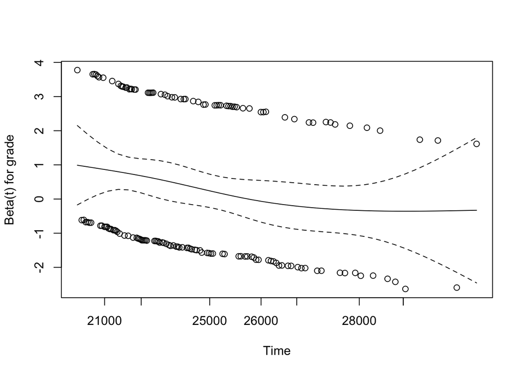

```r
plot(cox.zph(cox_age))
```